# Zagłębiając się w ggplot2

*Przemyslaw Biecek*

Sposób pracy z grafiką zilustrują nam dwa przypadku użycia

```r
library(Hmisc)   # ważone średnie
library(dplyr)   # obróbka danych
library(ggplot2) # grafika
load("PISAeurope.rda")

#
# dla każdego kraju i dla każdej grupy 'liczba książek w domu' potrzebujemy
# - średniego ważonego wyniku
# - dolnej i górnej granicy dla błędu

avgs <-
  pisa %>%
     filter(CNT %in% c('Poland', 'Germany')) %>%
     group_by(CNT, ST28Q01) %>%
     summarise(math = wtd.mean(PV1MATH, W_FSTUWT, na.rm=TRUE),
               sd = sqrt(wtd.var(PV1MATH, W_FSTUWT, na.rm=TRUE)),
               n = n(),
               lmath = math - 1.96* sd/sqrt(n),
               umath = math + 1.96* sd/sqrt(n))
avgs <- na.omit(avgs)
```

## Przypadek użycia 1

Zagadnienie:

Zależność pomiędzy wynikami z matematyki lub czytania a krajem i liczbą książek w domu.

Możliwe rozwiązania:

Dla dwóch krajów, np. dla POL i GER, przedstaw średnie wyniki i zaznacz słupki błędów +- 2 x se wokół średniej.

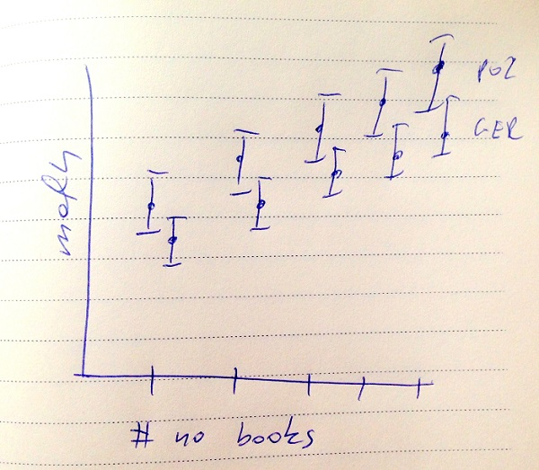

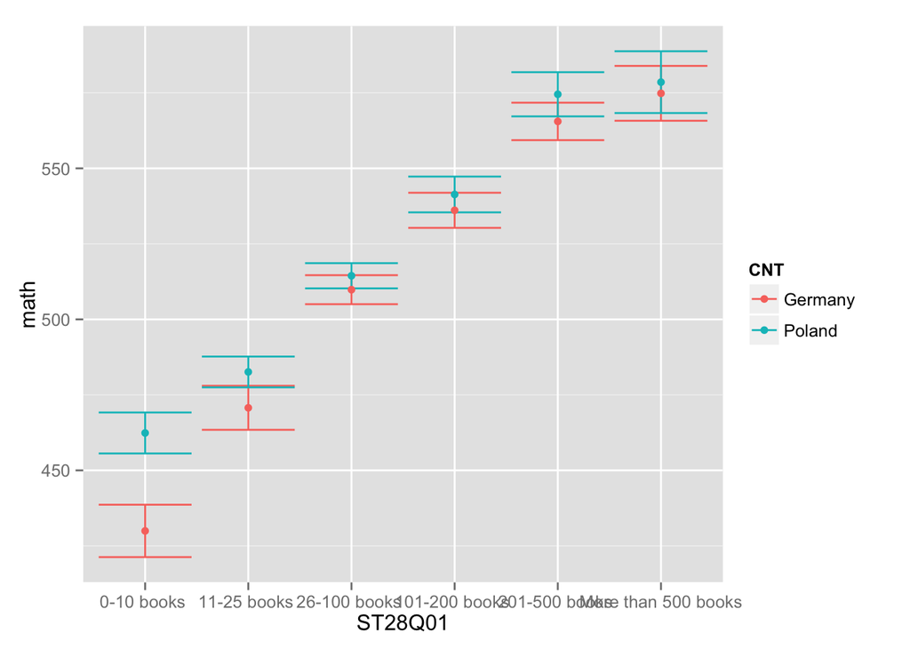

```r
# połączmy dwie geometrie, errorbar i points

ggplot(avgs, aes(x=ST28Q01, y=math, colour=CNT)) +
    geom_errorbar(aes(ymin=lmath, ymax=umath)) +
    geom_point()
```

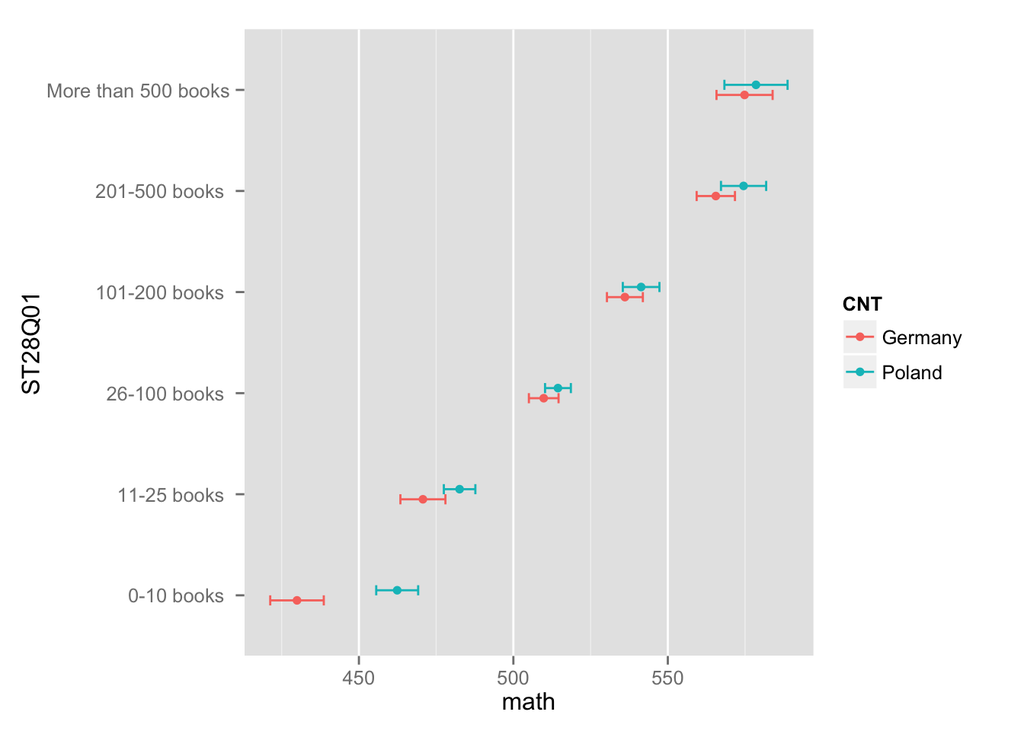

```r
# czas na dopracowanie szczegółów

ggplot(avgs, aes(x=ST28Q01, y=math, colour=CNT)) +
    geom_errorbar(aes(ymin=lmath, ymax=umath),
        width=0.2,
        position=position_dodge(.2)) +
    geom_point(
        position=position_dodge(.2)) +
    coord_flip() +
    theme(panel.grid.major.y=element_blank())
```

## Przypadek użycia 2

Zagadnienie:

Pokaż zależność pomiędzy wynikami a liczbą książek w domu, ale tym razem informacje o wynikach należy zamienić na zmienną jakościową.

Możliwe rozwiązania:

Wykres słupkowy z zaznaczonymi frakcjami osób o niskich/średnich/wysokich wynikach w zależności od zmiennej jakościowej ‘liczba książek w domu’.

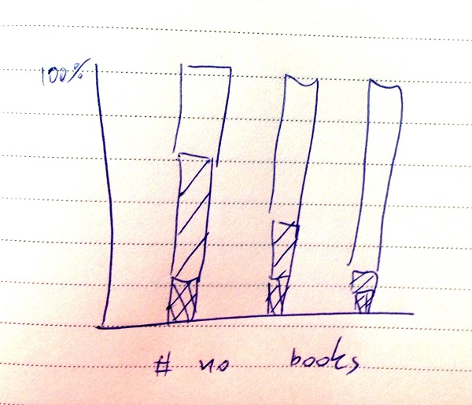

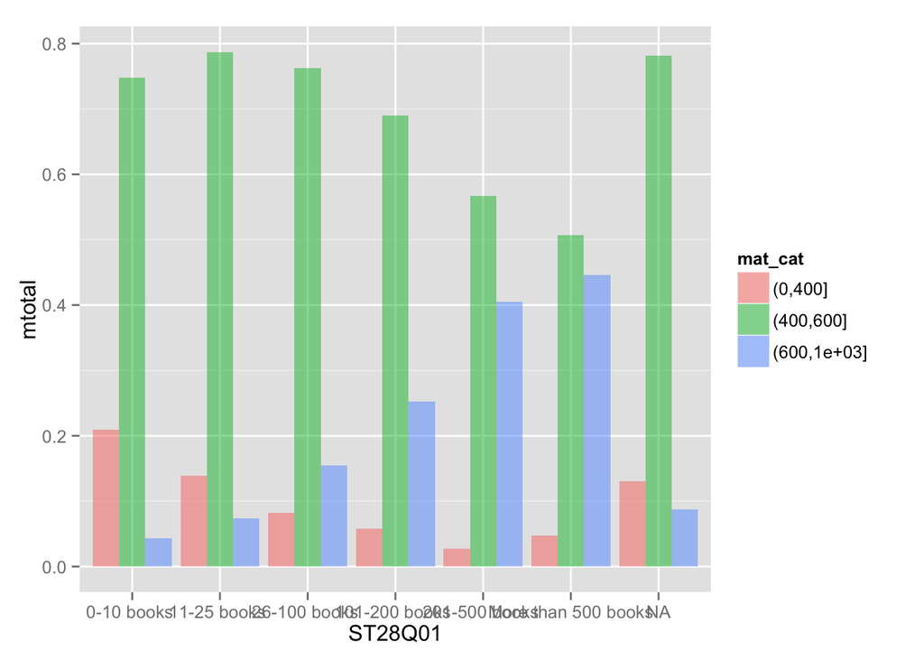

```r
# wyniki dzielimy na przedziały z progami odcięcia 400 i 600
# musimy policzyć ważone frakcje uczniów dla każdej kategorii pytania ST28Q01

pol <- pisa %>% filter(CNT == 'Poland')

props <-
  pol %>%
     mutate(mat_cat = cut(PV1MATH, c(0, 400, 600, 1000))) %>%
     group_by(ST28Q01, mat_cat) %>%
     summarise(total = sum(W_FSTUWT, na.rm=TRUE))
mprops <-
  props %>%
  group_by(ST28Q01) %>%
  mutate(mtotal = total / sum(total))

#
# teraz pozostaje jedynie zastosować geometrie geom_bar()
ggplot(mprops, aes(x=ST28Q01, y=mtotal, fill=mat_cat)) +
  geom_bar(stat='identity', position='dodge', alpha=0.5)
```

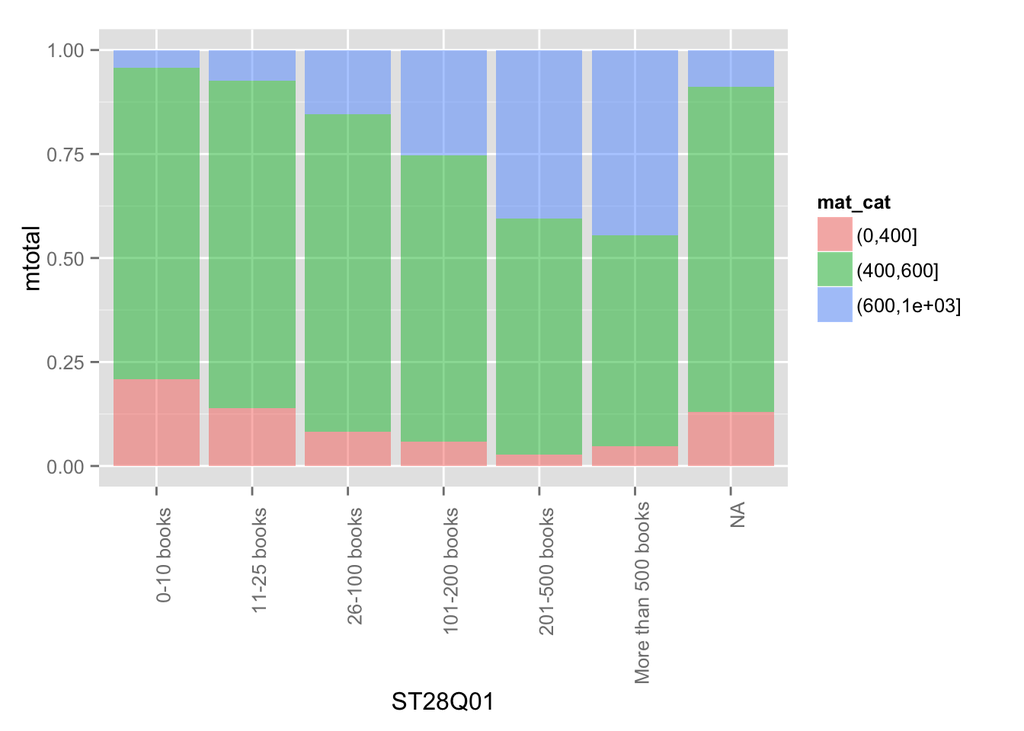

```r
ggplot(mprops, aes(x=ST28Q01, y=mtotal, fill=mat_cat)) +
  geom_bar(stat='identity', position='fill', alpha=0.5) +
   theme(axis.text.x = element_text(angle=90, hjust=1))
```

## Adnotacje

Aby zmienić etykiety na osiach x/y należy można funkcji ggtitle(), xlab(), ylab()

## Panele

Aby przedstawić jedną lub kilka zmiennych grupujących na jednym wykresie możemy wykorzystać mapowania.

Ale czasem bardziej odpowiednie jest przedstawienie rożnych grup na sąsiednich panelach.

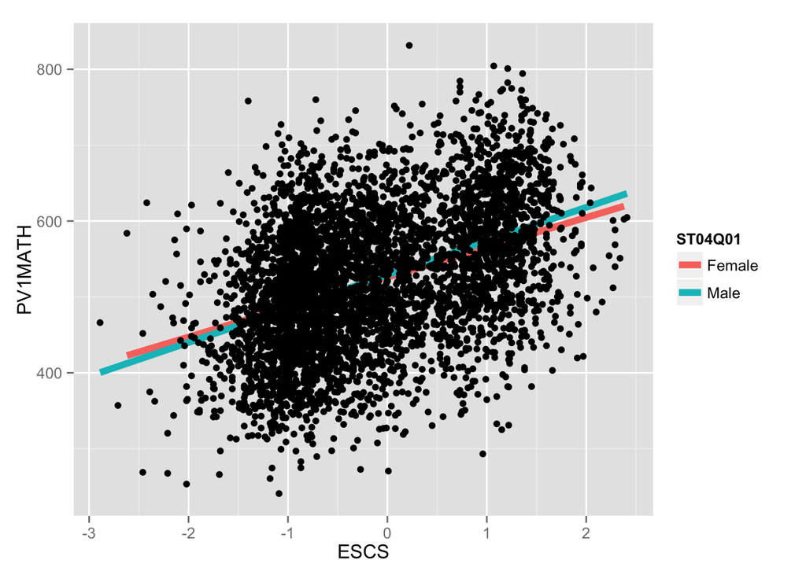

```r
  ggplot(pol, aes(x=ESCS, y=PV1MATH)) +
    geom_smooth(aes(colour=ST04Q01), se = FALSE, size=2, method = "lm") +
    geom_point()
```

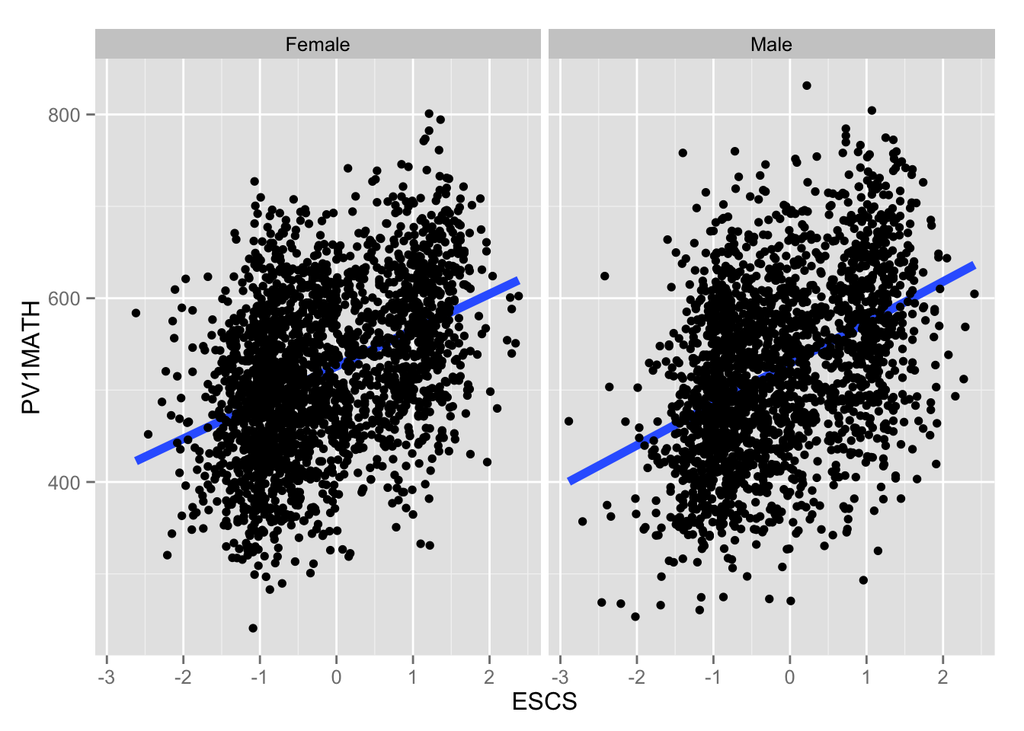

```r
  ggplot(pol, aes(x=ESCS, y=PV1MATH)) +
    geom_smooth(se = FALSE, size=2, method = "lm") +
    geom_point() +
    facet_wrap(~ST04Q01)
```

Na dwa sposoby można określić jak panele mają być rozmieszczone. Służą do tego funkcje facet_wrap() i facet_grid().

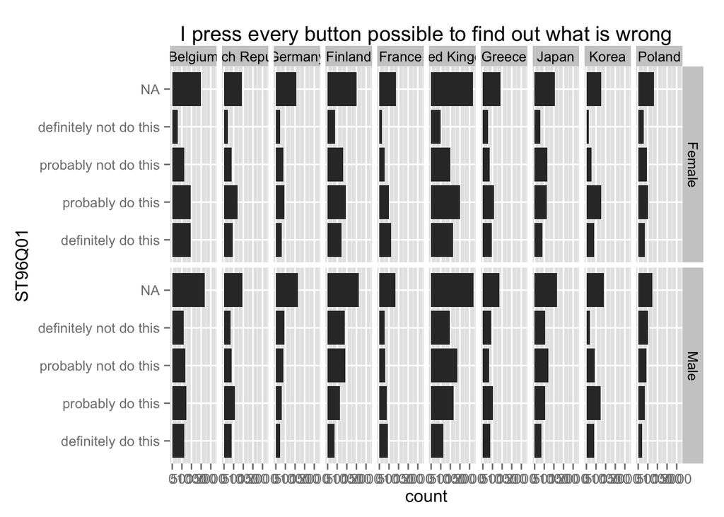

```r
ggplot(pisa, aes(x=ST96Q01)) +
  geom_bar(position="dodge") +
  ggtitle("I press every button possible to find out what is wrong") +
  coord_flip() +
  facet_grid(ST04Q01~CNT)
```

## Mapowania i skale

Aby pokazać kilka nowych możliwości zmiany mapowań i skal, potrzebujemy rozszerzonego zbioru danych.

```r
genderAvgs <- pisa %>%
          group_by(CNT, ST04Q01) %>%
          summarise(math = weighted.mean(PV1MATH, W_FSTUWT, na.rm = TRUE),
                    read = weighted.mean(PV1READ, W_FSTUWT, na.rm = TRUE),
                    total = sum(W_FSTUWT))
head(genderAvgs)
```

```
## Source: local data frame [6 x 5]
## Groups: CNT
##
##              CNT ST04Q01  math  read  total
## 1        Belgium  Female 511.9 525.3  58719
## 2        Belgium    Male 518.0 493.0  59170
## 3 Czech Republic  Female 493.0 513.7  40072
## 4 Czech Republic    Male 504.3 474.2  42178
## 5        Germany  Female 506.8 530.1 371885
## 6        Germany    Male 520.3 486.2 385022
```

Używając geometrii geom_point() możemy teraz określić kolor, kształt i wielkość.

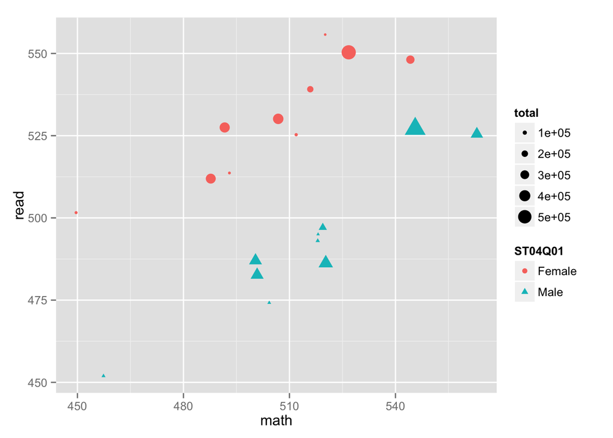

```r
ggplot(genderAvgs, aes(x=math, y=read, size=total, shape=ST04Q01, colour=ST04Q01)) +
    geom_point()
```

Zobaczmy co się dzieje w zależności od tego które zmienne są mapowane na jakie właściwości wykresu.

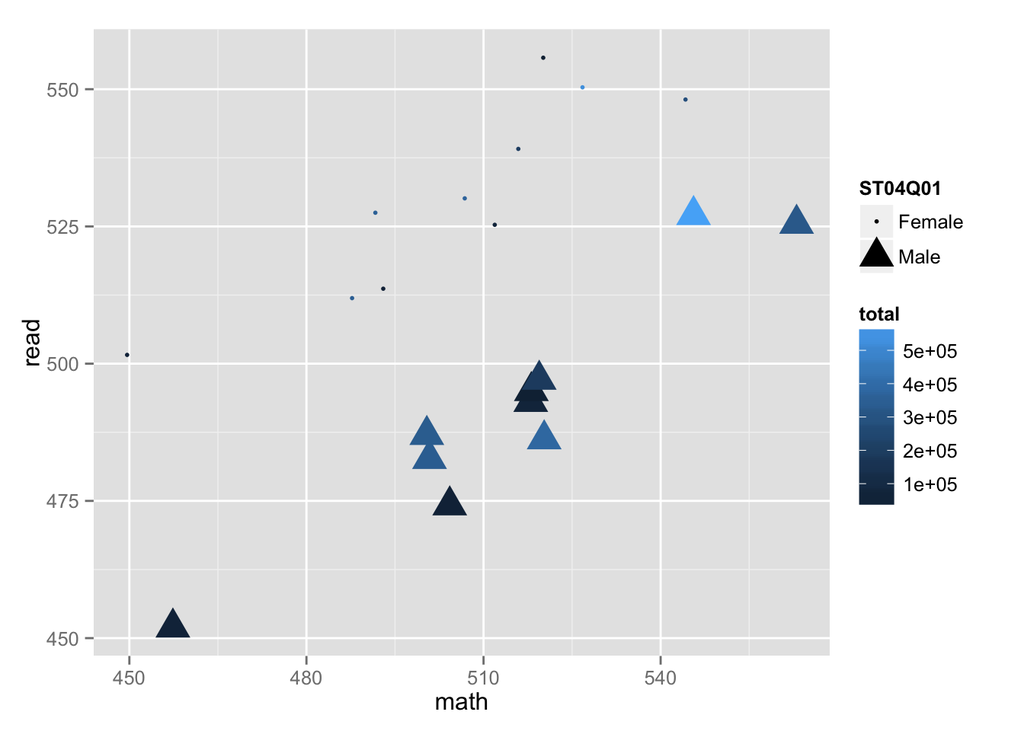

```r
ggplot(genderAvgs, aes(x=math, y=read, size=ST04Q01, shape=ST04Q01, colour=total)) +
    geom_point()
```

W pewnych, rzadkich, przypadkach pakiet ggplot2 nie potrafi automatycznie skonstruować dobrego mapowania. W takich przypadkach można to zrobić ręcznie.

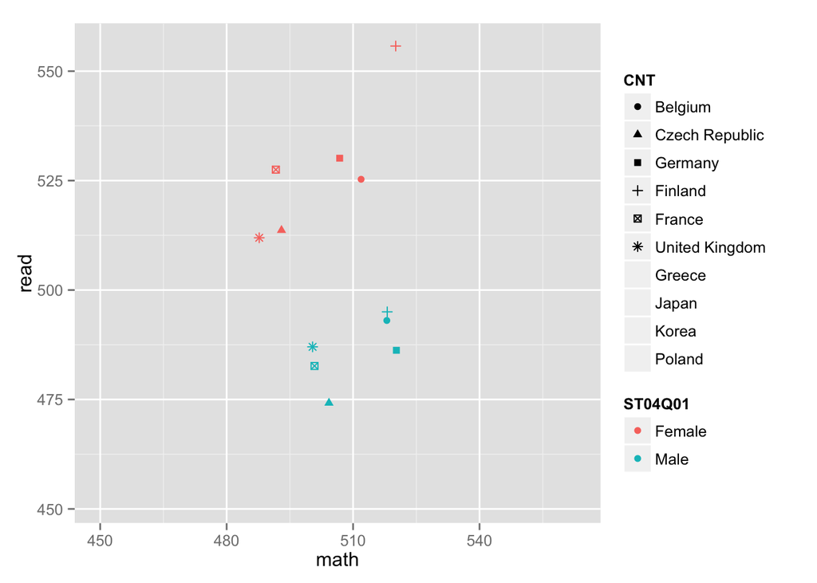

```r
# Problem with number of levels
ggplot(genderAvgs, aes(x=math, y=read, shape=CNT, colour=ST04Q01)) +
    geom_point()
```

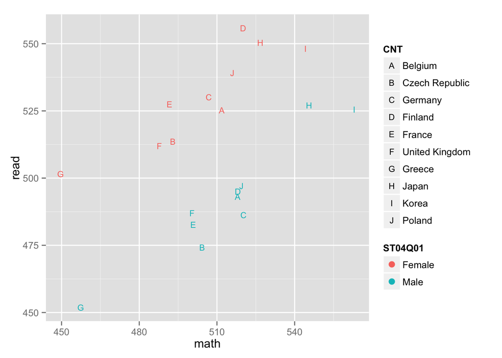

```r
ggplot(genderAvgs, aes(x=math, y=read, shape=CNT, colour=ST04Q01)) +
    geom_point(size=3) +
  scale_shape_manual(values=LETTERS[1:10])
```

W podobny sposób można modyfikować inne mapowania.

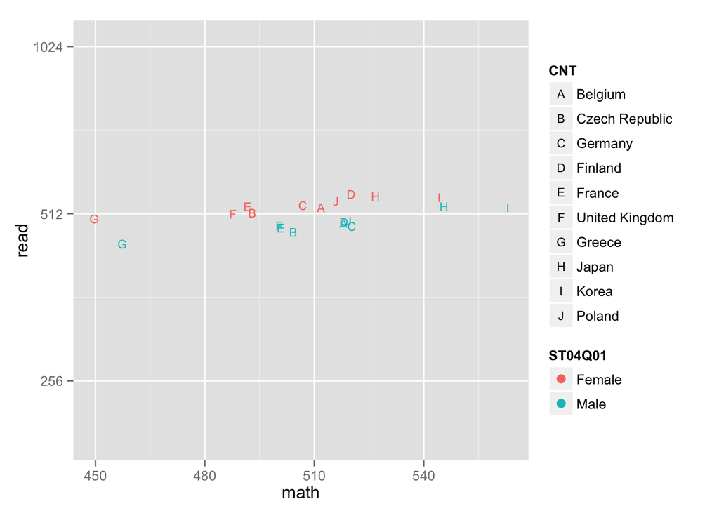

```r
ggplot(genderAvgs, aes(x=math, y=read, shape=CNT, colour=ST04Q01)) +
    geom_point(size=3) +
  scale_shape_manual(values=LETTERS[1:10]) +
  scale_y_continuous(trans="log2", limits=c(200,1050))
```

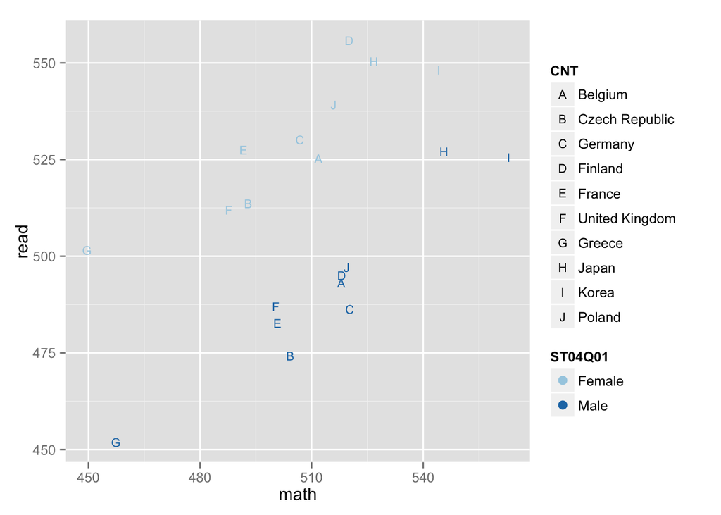

```r
ggplot(genderAvgs, aes(x=math, y=read, shape=CNT, colour=ST04Q01)) +
    geom_point(size=3) +
  scale_shape_manual(values=LETTERS[1:10]) +
  scale_color_brewer(palette="Paired")
```

W jaki sposób zmienić skale kolorów?

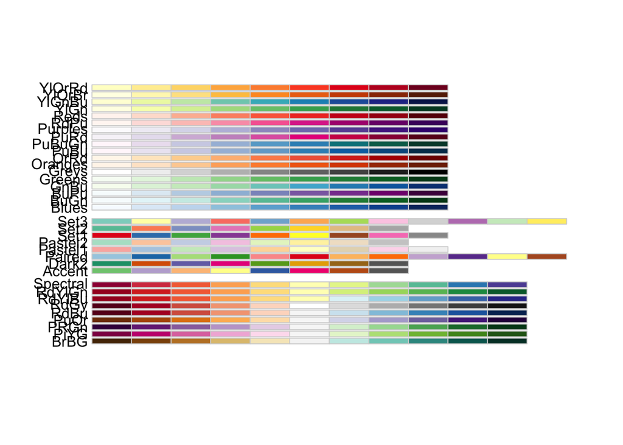

```r
# więcej skal kolorów Brewer
library(RColorBrewer)
display.brewer.all()
```

### Osie wykresu

Jeżeli na obu osiach prezentowane są wartości w tej samej jednostce, to dobrym pomysłem może być wymuszenie by również jednostki na wykresie były proporcjonalne.

```r
ggplot(genderAvgs, aes(x=math, y=read, shape=CNT, colour=ST04Q01)) +
    geom_point(size=3) +
  scale_shape_manual(values=LETTERS[1:10]) +
  coord_equal()
```

[output not shown]